# R Final Project

Joseph Elikishvili

August 9, 2016

Loading necessary libraries

Creating a subset “subflights”

Creating a new column that will store Date

```
##      Year Month DayofMonth UniqueCarrier DepDelay Cancelled
## 5424 2011     1          1            AA        0         0
## 5425 2011     1          2            AA        1         0
## 5426 2011     1          3            AA       -8         0
## 5427 2011     1          4            AA        3         0
## 5428 2011     1          5            AA        5         0
## 5429 2011     1          6            AA       -1         0
##      CancellationCode   Date
## 5424                  201111
## 5425                  201112
## 5426                  201113
## 5427                  201114
## 5428                  201115
## 5429                  201116
```

Removing unneeded Columns

```
##      UniqueCarrier DepDelay Cancelled CancellationCode   Date
## 5424            AA        0         0                  201111
## 5425            AA        1         0                  201112
## 5426            AA       -8         0                  201113
## 5427            AA        3         0                  201114
## 5428            AA        5         0                  201115
## 5429            AA       -1         0                  201116
```

#### 2. Attempting to answer the following question: Which is the most reliable Airline? By looking at relative cancelation rates due to Airline Fault, Comparing Departure Delays and Arrival Delays by Airline.

Looking at Cancelation data by Carriers in order to see which carrier has the highest flight cancealation rate due to Carrier Fault.

Cleaning Dataset and binding the data

Calculating Cancelation rate per Airline and displaying final dataset

```
##    carriers flights cancelations cancelrate
## 1        AA    3244           20     0.0062
## 2        B6     695            5     0.0072
## 3        CO   70032           37     0.0005
## 4        DL    2641           13     0.0049
## 5        EV    2204           60     0.0272
## 6        F9     838            2     0.0024
## 7        FL    2139            8     0.0037
## 8        MQ    4648           39     0.0084
## 9        OO   16061          121     0.0075
## 10       UA    2072           21     0.0101
## 11       US    4082           27     0.0066
## 12       WN   45343          517     0.0114
## 13       XE   73053          331     0.0045
## 14       YV      79            1     0.0127
```

Plotting Cancellation Rate by Airlines

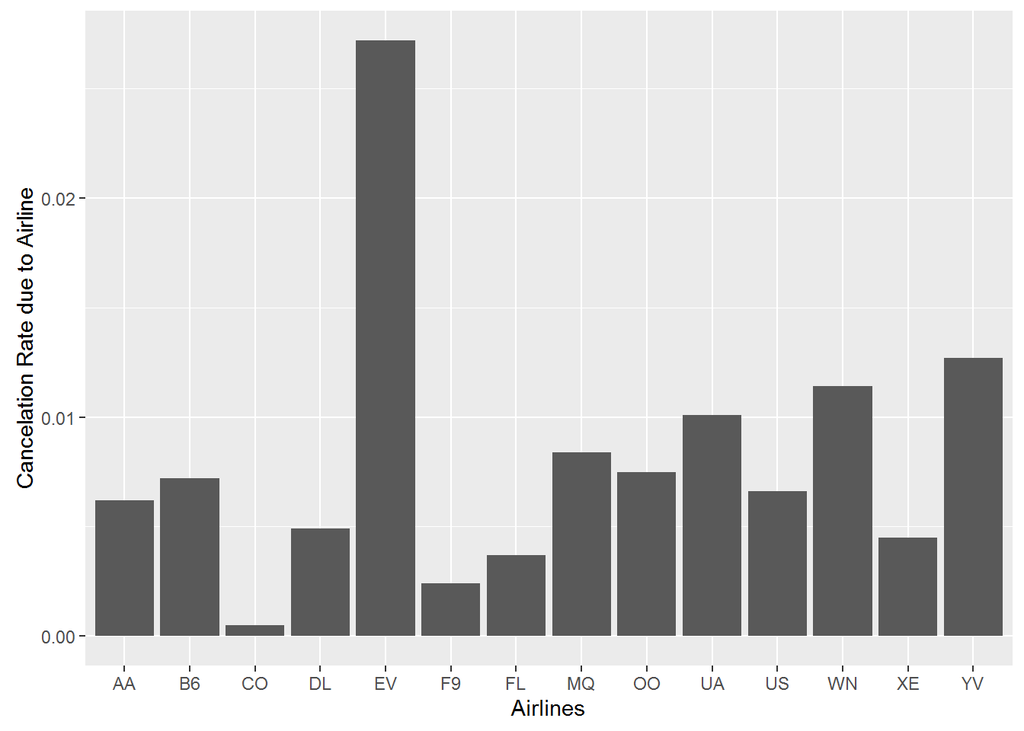

Comparing Mean Departure Delay by Airlines

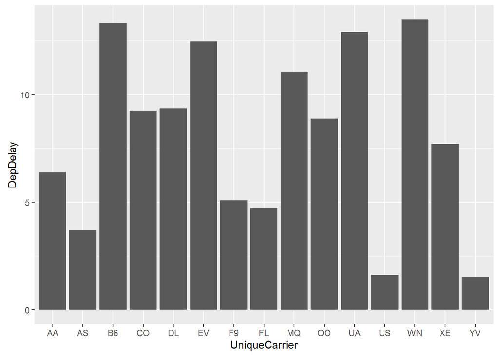

Comparing Mean Arrival Delay by Airlines

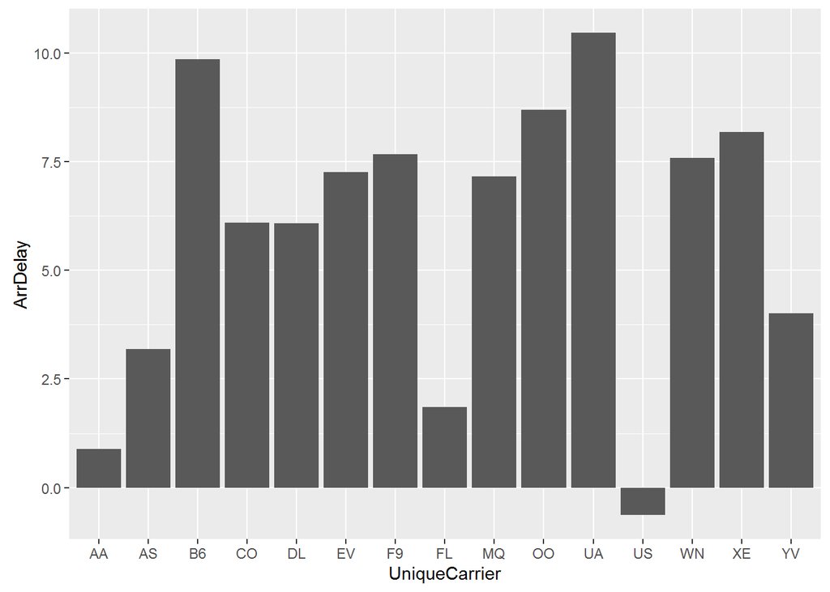

#### 3. Looking at “Origin” Airports to see which one is a faster option for traveling by comparing an average Departure Delay and Arrival Delay times.

Comparing Mean Departure Delay Times in 2 Airports

```
##   Origin  DepDelay
## 1    HOU 12.837873
## 2    IAH  8.436951
```

Comparng Mean Arrival Delay Times in 2 Airports

```
##   Origin ArrDelay
## 1    HOU 7.487946
## 2    IAH 6.977301
```

Comparing Mean Taxin Times in 2 Airports

```
##   Origin   TaxiIn
## 1    HOU 5.150205
## 2    IAH 6.380680
```

Comparing Mean Taxiout Times in 2 Airports

```
##   Origin   TaxiOut
## 1    HOU  9.123702
## 2    IAH 16.864243
```

#### After looking at Airlines one can notice that they all have a pretty respectable statistics as far as cancelation rates and pretty reasonable average Departure and Arrival Delays. Having said that, for the purposes of this study, I would recommend avoiding EV, B6, WN, UA and would recommend using US and FL.

#### After evaluating Departure and Arrival Delays in HOU and IAH airports. It appears that IAH has lower both mean Arrival and mean Departure Delay times, making it a faster option for the end user. I took a quick look at avergae Taxin and Taxiout times to see if they affect delays, but it appears that they do not seem to be affecting the delay times. IAH has lower delay times but higher TAXI in and TAXOUT times possibly due to the higher number of flights, but these numbers are still not affecting the relative performance compared to HOU which has higher mean Delay times but lower mean TAXI times.